# Organic Food Baskets

### **Goal:** Re-organize the layout of the store to maximize sales. To do so, Apples to Audiences wants to know what types of groceries are typically purchased together.

### **Question:** What items can be placed together?

```python
# If you'd like to install packages that aren't installed by default, list them here.
# This will ensure your notebook has all the dependencies and works everywhere

import sys
!{sys.executable} -m pip install xgboost sklearn
```

```python
# Import libraries
import numpy as np
import pandas as pd
import matplotlib.pyplot as plt

# modeling
from sklearn.decomposition import PCA
from sklearn.cluster import KMeans
```

```python
# Read in data
items = pd.read_csv("items.csv")
users = pd.read_csv("users.csv")
users_by_items = pd.read_csv("users_by_items.csv")
```

### Exploratory Data Analysis

```python
# What do the data look like?
def display_and_print_len(df):
    """ takes a df and prints the length and displays it """
    print('Length is: {}'.format(len(df)))
    display(df)

for d in [items,users,users_by_items]:
    display_and_print_len(d)
```

```
Length is: 48
```

|  | item_name | Item_id | price |
| --- | --- | --- | --- |
| 0 | sugar | 1 | 2 |
| 1 | lettuce | 2 | 1 |
| 2 | pet items | 3 | 2 |
| 3 | baby items | 4 | 4 |
| 4 | waffles | 5 | 2 |
| 5 | poultry | 6 | 4 |
| 6 | sandwich bags | 7 | 3 |
| 7 | butter | 8 | 3 |
| 8 | soda | 9 | 1 |
| 9 | carrots | 10 | 1 |
| 10 | cereals | 11 | 3 |
| 11 | shampoo | 12 | 3 |
| 12 | bagels | 13 | 2 |
| 13 | eggs | 14 | 2 |
| 14 | aluminum foil | 15 | 4 |
| 15 | milk | 16 | 3 |
| 16 | beef | 17 | 4 |
| 17 | laundry detergent | 18 | 7 |
| 18 | shaving cream | 19 | 2 |
| 19 | grapefruit | 20 | 2 |
| 20 | cheeses | 21 | 2 |
| 21 | frozen vegetables | 22 | 1 |
| 22 | tea | 23 | 3 |
| 23 | paper towels | 24 | 2 |
| 24 | cherries | 25 | 3 |
| 25 | spaghetti sauce | 26 | 2 |
| 26 | dishwashing | 27 | 6 |
| 27 | canned vegetables | 28 | 1 |
| 28 | hand soap | 29 | 3 |
| 29 | flour | 30 | 2 |
| 30 | pasta | 31 | 1 |
| 31 | apples | 32 | 2 |
| 32 | toilet paper | 33 | 2 |
| 33 | tortillas | 34 | 2 |
| 34 | soap | 35 | 3 |
| 35 | ice cream | 36 | 3 |
| 36 | dinner rolls | 37 | 2 |
| 37 | juice | 38 | 3 |
| 38 | sandwich loaves | 39 | 2 |
| 39 | berries | 40 | 3 |
| 40 | ketchup | 41 | 1 |
| 41 | cucumbers | 42 | 1 |
| 42 | coffee | 43 | 5 |
| 43 | broccoli | 44 | 1 |
| 44 | cauliflower | 45 | 1 |
| 45 | bananas | 46 | 1 |
| 46 | pork | 47 | 4 |
| 47 | yogurt | 48 | 1 |

```
Length is: 39474
```

|  | user_id | id |
| --- | --- | --- |
| 0 | 222087 | 27,26 |
| 1 | 1343649 | 6,47,17 |
| 2 | 404134 | 18,12,23,22,27,43,38,20,35,1 |
| 3 | 1110200 | 9,23,2,20,26,47,37 |
| 4 | 224107 | 31,18,5,13,1,21,48,16,26,2,44,32,20,37,42,35,4... |
| 5 | 409803 | 43,29,8,37,23,45 |
| 6 | 1296632 | 18,15,31,11,20,32,25,6,47 |
| 7 | 748280 | 14,43,6,20,7,42,41,28,10,22,46 |
| 8 | 31625 | 1,43,31,37,25,32,28,35 |
| 9 | 987613 | 27,1,3,2,11,45,10,44,15 |
| 10 | 560265 | 10,31,25,19,2,7,15,9,23 |
| 11 | 60201 | 26,28,13,39,27,22,48,18,16,17,32 |
| 12 | 1413771 | 10,30,17,45,35,2,11,3,43 |
| 13 | 925776 | 43,38,35,28,16 |
| 14 | 455303 | 38,15,48,43,44,10,32 |
| 15 | 713697 | 2,42,18 |
| 16 | 226213 | 48,32,16,21,13,37,34,39 |
| 17 | 392460 | 37,38,9 |
| 18 | 445179 | 44,37,33,39,9,43,13,8,21,48 |
| 19 | 176016 | 39,21,16,2,13,37,48,10,6,28,5 |
| 20 | 1158400 | 23,43,9,40,28 |
| 21 | 1275545 | 9,43,38,47,17,25,40 |
| 22 | 772450 | 41,19,23,7,18,40,25,1 |
| 23 | 1215832 | 41 |
| 24 | 386957 | 13,1,29,7,10,35,17,43,46,37,18,26 |
| 25 | 377243 | 2 |
| 26 | 76657 | 25,30,40,37,23,47,32,45 |
| 27 | 644868 | 46,25,47,39,26,12,38,9,21,13,6,1 |
| 28 | 1141513 | 15,23,17 |
| 29 | 867267 | 44,10,26,39 |
| ... | ... | ... |
| 39444 | 1300636 | 46,25,40,42,27,32,47,30,31,14,22,45,38,23 |
| 39445 | 763285 | 43 |
| 39446 | 953878 | 6,32,25,36,9,40,47,46,24,22,2,34,41 |
| 39447 | 1405771 | 27,31,5,46,21,43,11,39,44,10 |
| 39448 | 845798 | 24,33,42 |
| 39449 | 20054 | 42,21,16,2,47,25 |
| 39450 | 876310 | 2,10,43,41,34 |
| 39451 | 934118 | 38,36,23,22 |
| 39452 | 512741 | 41,42,2,45,27,32,44 |
| 39453 | 1373317 | 16,48,1,4,26,38,25,37 |
| 39454 | 389222 | 9,33,1 |
| 39455 | 527123 | 29,13,10,17,18,25,40,36,46,20,28,44,45 |
| 39456 | 1036226 | 20,34,30,47,17,19,29,21,23,38,9,44 |
| 39457 | 199217 | 17,6,47,11,20,37,34 |
| 39458 | 638358 | 24,10,40,46 |
| 39459 | 1479453 | 22,47 |
| 39460 | 1184522 | 20 |
| 39461 | 1398041 | 38,1,24,46,33,48,8,10,44,30,40,6 |
| 39462 | 1330906 | 2,45,18 |
| 39463 | 1499087 | 36,2,38,35,28,26,43,47,29,22 |
| 39464 | 1494796 | 38,2,44,43,46 |
| 39465 | 587211 | 13,39,34,27,11,31,26,41,2,8 |
| 39466 | 755085 | 18,21,17,47,6,25,20,45,19 |
| 39467 | 922812 | 46,35 |
| 39468 | 1055933 | 9,43,15,3,44,45,10,41 |
| 39469 | 704794 | 48,42,44,10,2 |
| 39470 | 31237 | 23,21,26,27,41,9,47,43,20,40,16,24,46 |
| 39471 | 724925 | 3,39,28,4,1,43,47,27,18,25,44,10,30,2 |
| 39472 | 651509 | 13,39,20,32,37,1,3,18,34 |
| 39473 | 517744 | 39,40,20,3,10,42,38,43,28,25,13 |

39474 rows × 2 columns

```
Length is: 24885
```

|  | user_id | 1 | 2 | 3 | 4 | 5 | 6 | 7 | 8 | 9 | ... | 39 | 40 | 41 | 42 | 43 | 44 | 45 | 46 | 47 | 48 |
| --- | --- | --- | --- | --- | --- | --- | --- | --- | --- | --- | --- | --- | --- | --- | --- | --- | --- | --- | --- | --- | --- |
| 0 | 100002 | 0 | 0 | 0 | 0 | 0 | 0 | 0 | 0 | 0 | ... | 0 | 0 | 0 | 1 | 0 | 0 | 1 | 0 | 0 | 0 |
| 1 | 1000074 | 0 | 1 | 0 | 0 | 0 | 0 | 1 | 1 | 0 | ... | 1 | 2 | 0 | 0 | 1 | 0 | 1 | 1 | 0 | 1 |
| 2 | 100009 | 1 | 0 | 0 | 0 | 0 | 1 | 0 | 0 | 1 | ... | 2 | 0 | 1 | 0 | 0 | 0 | 1 | 0 | 0 | 0 |
| 3 | 1000096 | 0 | 0 | 0 | 0 | 0 | 0 | 0 | 0 | 0 | ... | 1 | 0 | 1 | 0 | 1 | 0 | 0 | 0 | 0 | 0 |
| 4 | 1000103 | 0 | 1 | 0 | 0 | 0 | 2 | 0 | 1 | 1 | ... | 2 | 1 | 0 | 1 | 1 | 2 | 1 | 1 | 0 | 1 |
| 5 | 1000107 | 0 | 0 | 1 | 0 | 0 | 0 | 0 | 0 | 2 | ... | 0 | 1 | 0 | 0 | 0 | 1 | 1 | 0 | 0 | 0 |
| 6 | 1000145 | 1 | 0 | 1 | 0 | 0 | 0 | 0 | 0 | 0 | ... | 1 | 0 | 0 | 1 | 0 | 0 | 0 | 1 | 0 | 0 |
| 7 | 1000236 | 0 | 1 | 0 | 0 | 0 | 0 | 0 | 0 | 0 | ... | 1 | 1 | 0 | 1 | 0 | 1 | 0 | 0 | 0 | 0 |
| 8 | 1000256 | 0 | 0 | 1 | 0 | 0 | 0 | 0 | 0 | 0 | ... | 0 | 0 | 0 | 1 | 0 | 1 | 0 | 0 | 1 | 0 |
| 9 | 1000289 | 1 | 1 | 0 | 0 | 0 | 1 | 0 | 0 | 0 | ... | 0 | 0 | 1 | 0 | 0 | 1 | 1 | 0 | 0 | 0 |
| 10 | 1000296 | 0 | 1 | 0 | 0 | 0 | 0 | 0 | 0 | 0 | ... | 0 | 0 | 1 | 0 | 0 | 1 | 1 | 0 | 0 | 0 |
| 11 | 1000355 | 0 | 0 | 0 | 1 | 0 | 1 | 0 | 1 | 0 | ... | 2 | 0 | 0 | 0 | 1 | 0 | 0 | 1 | 0 | 0 |
| 12 | 1000359 | 1 | 0 | 0 | 0 | 0 | 0 | 0 | 0 | 0 | ... | 0 | 0 | 0 | 0 | 0 | 0 | 0 | 0 | 0 | 0 |
| 13 | 1000499 | 1 | 1 | 0 | 0 | 0 | 1 | 1 | 1 | 0 | ... | 0 | 0 | 0 | 1 | 0 | 1 | 1 | 0 | 1 | 0 |
| 14 | 1000584 | 0 | 1 | 1 | 0 | 0 | 1 | 0 | 0 | 0 | ... | 0 | 0 | 0 | 0 | 1 | 0 | 0 | 1 | 0 | 1 |
| 15 | 1000656 | 0 | 0 | 0 | 0 | 0 | 0 | 0 | 0 | 0 | ... | 0 | 0 | 0 | 0 | 0 | 0 | 0 | 0 | 0 | 0 |
| 16 | 1000664 | 0 | 0 | 0 | 0 | 0 | 0 | 0 | 0 | 0 | ... | 0 | 0 | 1 | 0 | 1 | 0 | 0 | 0 | 0 | 0 |
| 17 | 1000679 | 0 | 0 | 1 | 0 | 0 | 0 | 0 | 0 | 0 | ... | 0 | 0 | 0 | 0 | 0 | 1 | 1 | 0 | 0 | 0 |
| 18 | 1000683 | 1 | 3 | 0 | 0 | 2 | 0 | 1 | 1 | 2 | ... | 1 | 2 | 0 | 2 | 1 | 3 | 2 | 2 | 1 | 0 |
| 19 | 1000840 | 0 | 1 | 1 | 0 | 0 | 0 | 0 | 0 | 0 | ... | 0 | 0 | 0 | 0 | 1 | 0 | 1 | 0 | 0 | 0 |
| 20 | 1000841 | 0 | 2 | 0 | 0 | 0 | 1 | 1 | 0 | 0 | ... | 1 | 3 | 0 | 0 | 0 | 0 | 0 | 2 | 1 | 0 |
| 21 | 1000847 | 1 | 0 | 0 | 0 | 0 | 0 | 1 | 0 | 0 | ... | 1 | 0 | 0 | 0 | 0 | 0 | 0 | 0 | 0 | 0 |
| 22 | 1000857 | 1 | 0 | 0 | 0 | 0 | 0 | 0 | 0 | 0 | ... | 0 | 0 | 0 | 1 | 0 | 0 | 0 | 0 | 0 | 0 |
| 23 | 1000931 | 0 | 0 | 0 | 0 | 0 | 0 | 0 | 0 | 1 | ... | 0 | 0 | 0 | 0 | 0 | 0 | 0 | 0 | 0 | 0 |
| 24 | 1000961 | 1 | 0 | 0 | 1 | 0 | 1 | 0 | 0 | 1 | ... | 1 | 0 | 0 | 0 | 1 | 0 | 0 | 0 | 2 | 0 |
| 25 | 1001046 | 0 | 1 | 0 | 0 | 0 | 0 | 0 | 0 | 0 | ... | 0 | 0 | 0 | 1 | 0 | 0 | 0 | 0 | 1 | 0 |
| 26 | 1001170 | 0 | 0 | 0 | 0 | 0 | 1 | 0 | 0 | 0 | ... | 0 | 1 | 0 | 0 | 0 | 1 | 0 | 0 | 0 | 0 |
| 27 | 1001282 | 3 | 2 | 0 | 0 | 0 | 0 | 2 | 0 | 2 | ... | 1 | 2 | 0 | 1 | 1 | 2 | 1 | 2 | 2 | 2 |
| 28 | 1001334 | 0 | 0 | 0 | 0 | 0 | 0 | 1 | 0 | 0 | ... | 0 | 1 | 0 | 1 | 0 | 0 | 1 | 0 | 0 | 0 |
| 29 | 100134 | 1 | 0 | 0 | 0 | 0 | 0 | 0 | 1 | 0 | ... | 1 | 0 | 0 | 0 | 0 | 0 | 0 | 0 | 1 | 0 |
| ... | ... | ... | ... | ... | ... | ... | ... | ... | ... | ... | ... | ... | ... | ... | ... | ... | ... | ... | ... | ... | ... |
| 24855 | 99810 | 1 | 1 | 0 | 0 | 0 | 1 | 1 | 1 | 2 | ... | 1 | 0 | 1 | 1 | 0 | 0 | 2 | 2 | 1 | 0 |
| 24856 | 998113 | 0 | 1 | 0 | 0 | 0 | 1 | 0 | 1 | 0 | ... | 0 | 0 | 0 | 0 | 0 | 0 | 0 | 0 | 1 | 0 |
| 24857 | 998128 | 1 | 0 | 1 | 0 | 0 | 1 | 0 | 0 | 0 | ... | 1 | 0 | 0 | 0 | 0 | 0 | 0 | 0 | 0 | 0 |
| 24858 | 998143 | 0 | 2 | 0 | 0 | 0 | 1 | 0 | 0 | 0 | ... | 0 | 0 | 0 | 0 | 1 | 1 | 1 | 0 | 1 | 0 |
| 24859 | 998411 | 0 | 0 | 0 | 0 | 0 | 0 | 0 | 0 | 0 | ... | 0 | 0 | 0 | 0 | 1 | 1 | 1 | 0 | 0 | 0 |
| 24860 | 998448 | 0 | 1 | 0 | 0 | 0 | 1 | 0 | 1 | 0 | ... | 1 | 1 | 0 | 1 | 1 | 0 | 1 | 0 | 1 | 1 |
| 24861 | 9985 | 0 | 0 | 0 | 0 | 0 | 0 | 0 | 0 | 0 | ... | 0 | 0 | 0 | 0 | 0 | 0 | 0 | 0 | 0 | 0 |
| 24862 | 998550 | 1 | 0 | 1 | 0 | 0 | 1 | 0 | 0 | 0 | ... | 0 | 0 | 0 | 0 | 0 | 0 | 0 | 0 | 0 | 0 |
| 24863 | 998563 | 1 | 1 | 0 | 0 | 0 | 0 | 0 | 0 | 0 | ... | 1 | 0 | 0 | 0 | 1 | 0 | 0 | 0 | 1 | 0 |
| 24864 | 998638 | 1 | 1 | 1 | 0 | 1 | 0 | 0 | 1 | 1 | ... | 2 | 0 | 1 | 0 | 0 | 0 | 0 | 0 | 0 | 0 |
| 24865 | 998735 | 0 | 1 | 0 | 0 | 0 | 0 | 0 | 0 | 0 | ... | 0 | 1 | 1 | 0 | 0 | 1 | 0 | 0 | 0 | 0 |
| 24866 | 99878 | 2 | 2 | 0 | 0 | 0 | 0 | 0 | 0 | 0 | ... | 1 | 1 | 1 | 0 | 0 | 2 | 0 | 1 | 0 | 0 |
| 24867 | 99883 | 0 | 0 | 0 | 0 | 0 | 1 | 0 | 0 | 0 | ... | 0 | 0 | 0 | 0 | 0 | 0 | 0 | 0 | 0 | 0 |
| 24868 | 99888 | 0 | 0 | 1 | 1 | 0 | 0 | 0 | 0 | 0 | ... | 0 | 1 | 0 | 0 | 0 | 0 | 1 | 1 | 0 | 1 |
| 24869 | 998927 | 1 | 0 | 0 | 0 | 0 | 0 | 0 | 0 | 1 | ... | 0 | 0 | 0 | 1 | 0 | 1 | 0 | 0 | 0 | 0 |
| 24870 | 99906 | 0 | 1 | 0 | 0 | 0 | 0 | 0 | 0 | 0 | ... | 0 | 0 | 0 | 0 | 0 | 0 | 0 | 0 | 0 | 0 |
| 24871 | 999074 | 0 | 0 | 0 | 0 | 0 | 1 | 0 | 1 | 0 | ... | 0 | 0 | 0 | 0 | 1 | 1 | 0 | 0 | 1 | 0 |
| 24872 | 999114 | 0 | 1 | 0 | 1 | 0 | 0 | 0 | 0 | 1 | ... | 0 | 0 | 0 | 1 | 0 | 0 | 0 | 0 | 0 | 0 |
| 24873 | 999157 | 0 | 0 | 0 | 0 | 0 | 0 | 0 | 0 | 0 | ... | 0 | 0 | 0 | 0 | 0 | 1 | 0 | 0 | 0 | 0 |
| 24874 | 999221 | 0 | 0 | 0 | 0 | 1 | 0 | 1 | 1 | 0 | ... | 1 | 1 | 0 | 0 | 0 | 0 | 0 | 1 | 1 | 1 |
| 24875 | 999312 | 1 | 1 | 0 | 0 | 0 | 1 | 1 | 1 | 0 | ... | 0 | 0 | 1 | 0 | 0 | 0 | 0 | 0 | 2 | 1 |
| 24876 | 999362 | 0 | 1 | 0 | 0 | 0 | 1 | 0 | 0 | 0 | ... | 0 | 0 | 0 | 0 | 0 | 1 | 0 | 0 | 1 | 0 |
| 24877 | 999497 | 0 | 0 | 0 | 0 | 0 | 0 | 0 | 0 | 0 | ... | 0 | 0 | 0 | 1 | 0 | 1 | 0 | 0 | 0 | 0 |
| 24878 | 999502 | 0 | 1 | 0 | 0 | 0 | 0 | 0 | 0 | 1 | ... | 0 | 0 | 0 | 0 | 1 | 0 | 0 | 0 | 0 | 0 |
| 24879 | 999583 | 1 | 1 | 0 | 0 | 0 | 0 | 0 | 0 | 0 | ... | 1 | 0 | 1 | 0 | 1 | 0 | 0 | 1 | 0 | 0 |
| 24880 | 999640 | 1 | 0 | 1 | 0 | 0 | 1 | 0 | 0 | 1 | ... | 0 | 0 | 0 | 0 | 1 | 0 | 0 | 0 | 1 | 0 |
| 24881 | 999679 | 0 | 1 | 0 | 0 | 1 | 1 | 0 | 0 | 0 | ... | 0 | 0 | 0 | 0 | 1 | 1 | 0 | 1 | 1 | 0 |
| 24882 | 999776 | 0 | 0 | 1 | 0 | 0 | 1 | 0 | 0 | 0 | ... | 0 | 0 | 0 | 1 | 0 | 0 | 1 | 1 | 1 | 0 |
| 24883 | 999908 | 0 | 0 | 0 | 0 | 0 | 0 | 0 | 0 | 0 | ... | 0 | 0 | 0 | 0 | 0 | 0 | 0 | 0 | 0 | 0 |
| 24884 | 999995 | 1 | 0 | 0 | 0 | 0 | 0 | 0 | 0 | 1 | ... | 0 | 0 | 0 | 0 | 0 | 0 | 0 | 1 | 1 | 0 |

24885 rows × 49 columns

There are more rows in the users table (~39474) than there are in the users_by_items matrix (24885)!

```python
# Are there duplicate items in the items table?
display(items['item_name'].value_counts()) # nope!
```

```
tea                  1
baby items           1
tortillas            1
canned vegetables    1
juice                1
bagels               1
sandwich loaves      1
sugar                1
cheeses              1
berries              1
coffee               1
cucumbers            1
flour                1
laundry detergent    1
poultry              1
cherries             1
soda                 1
hand soap            1
milk                 1
beef                 1
shampoo              1
soap                 1
ice cream            1
shaving cream        1
lettuce              1
dishwashing          1
waffles              1
broccoli             1
cauliflower          1
pork                 1
sandwich bags        1
cereals              1
ketchup              1
paper towels         1
frozen vegetables    1
apples               1
yogurt               1
butter               1
pet items            1
eggs                 1
toilet paper         1
grapefruit           1
bananas              1
dinner rolls         1
aluminum foil        1
carrots              1
spaghetti sauce      1
pasta                1
Name: item_name, dtype: int64
```

```python
# Are there repeat users in the user table?
display(users['user_id'].value_counts()) #yes!
```

```
696000     7
31625      7
653800     7
884172     7
315516     6
          ..
916621     1
652428     1
840840     1
1401982    1
1023836    1
Name: user_id, Length: 24885, dtype: int64
```

There are between 1 and 7 orders per user. These seem to be why there are values > 1 in the users_by_items matrix.

## Analysis

1. Project items into a lower dimensionality space (e.g., not the vector of ~24000 users for each item)
2. Cluster the item vectors together user K-means
3. Identify clusters of items and make recommendations based on clusters.

### Projecting items into a lower dimensionality space

(In a perfect world I might use LightFM to perform NMF to get the item embeddings, but that could take a while to tune/run, so let's do something basic for now to get the pipeline working and level up later if we can )

Let's see if we can use PCA first to reduce the dimensionality

```python
users_by_items.set_index('user_id',inplace=True)
df = users_by_items.transpose()
display(df.head())
```

| user_id | 100002 | 1000074 | 100009 | 1000096 | 1000103 | 1000107 | 1000145 | 1000236 | 1000256 | 1000289 | ... | 999312 | 999362 | 999497 | 999502 | 999583 | 999640 | 999679 | 999776 | 999908 | 999995 |
| --- | --- | --- | --- | --- | --- | --- | --- | --- | --- | --- | --- | --- | --- | --- | --- | --- | --- | --- | --- | --- | --- |
| 1 | 0 | 0 | 1 | 0 | 0 | 0 | 1 | 0 | 0 | 1 | ... | 1 | 0 | 0 | 0 | 1 | 1 | 0 | 0 | 0 | 1 |
| 2 | 0 | 1 | 0 | 0 | 1 | 0 | 0 | 1 | 0 | 1 | ... | 1 | 1 | 0 | 1 | 1 | 0 | 1 | 0 | 0 | 0 |
| 3 | 0 | 0 | 0 | 0 | 0 | 1 | 1 | 0 | 1 | 0 | ... | 0 | 0 | 0 | 0 | 0 | 1 | 0 | 1 | 0 | 0 |
| 4 | 0 | 0 | 0 | 0 | 0 | 0 | 0 | 0 | 0 | 0 | ... | 0 | 0 | 0 | 0 | 0 | 0 | 0 | 0 | 0 | 0 |
| 5 | 0 | 0 | 0 | 0 | 0 | 0 | 0 | 0 | 0 | 0 | ... | 0 | 0 | 0 | 0 | 0 | 0 | 1 | 0 | 0 | 0 |

5 rows × 24885 columns

```python
num_pcs = 20
pca = PCA(n_components=num_pcs)
pca.fit(df)
df_pca = pd.DataFrame(pca.transform(df),columns=['PC{}'.format(x) for x in range(1,num_pcs+1)],
                           index=df.index)
display(df_pca.head())
```

|  | PC1 | PC2 | PC3 | PC4 | PC5 | PC6 | PC7 | PC8 | PC9 | PC10 | PC11 | PC12 | PC13 | PC14 | PC15 | PC16 | PC17 | PC18 | PC19 | PC20 |
| --- | --- | --- | --- | --- | --- | --- | --- | --- | --- | --- | --- | --- | --- | --- | --- | --- | --- | --- | --- | --- |
| 1 | 18.148261 | -2.732472 | 3.136347 | 2.998001 | -1.998577 | 41.372182 | 4.107854 | -22.986284 | 58.187888 | -4.225963 | -0.968105 | 2.291330 | 2.163431 | 9.101755 | -8.081205 | 5.343646 | -1.112538 | -7.490620 | 3.211306 | -3.154563 |
| 2 | 75.944069 | -31.192155 | -19.192963 | -0.282892 | -6.618068 | 49.679203 | -7.806288 | 4.834155 | -39.681168 | 4.984697 | -0.707639 | 2.543529 | -1.384468 | 8.339008 | 1.760506 | 2.301276 | 1.305669 | 3.475827 | -0.670396 | -4.066561 |
| 3 | 3.334319 | -2.444252 | -2.890900 | 1.593392 | -1.143392 | 22.943520 | -3.243384 | -17.601365 | 10.811179 | -6.629150 | -2.283902 | 3.174059 | -0.520482 | -26.920474 | 17.510221 | -7.156376 | 1.050305 | 12.734659 | -13.402433 | 3.410600 |
| 4 | -25.666322 | -2.327715 | -2.531033 | -0.198225 | -1.417053 | 5.069834 | -1.374733 | -8.594248 | -1.802545 | -0.085738 | -1.641293 | 0.979373 | -0.835645 | 3.195690 | 3.020253 | -1.197144 | -1.258309 | 4.288488 | -2.411754 | -1.301114 |
| 5 | -29.669377 | -2.332650 | -3.299389 | 0.223631 | -2.573050 | 1.833301 | 1.687389 | -7.209666 | -3.408377 | 0.317627 | -0.600846 | 2.906937 | 0.362680 | 2.234179 | 3.703149 | 0.973040 | -0.193369 | 0.511745 | -0.858826 | -2.813060 |

```
20
[0.09277056 0.04382244 0.03991651 0.0395982  0.03497656 0.02983582
 0.0267678  0.02524185 0.02513724 0.02270689 0.0224375  0.0222498
 0.02205089 0.02193611 0.02171791 0.0215748  0.02138928 0.02117624
 0.021069   0.02085847]
```

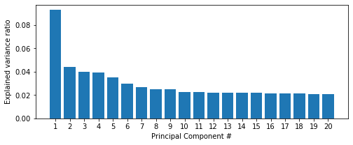

```python
# Looking at the explained_variance_ratio for PCA to see how many PCs to keep
print(len(pca.explained_variance_ratio_))
print(pca.explained_variance_ratio_)

fig,ax = plt.subplots(figsize=(8,3))
plt.bar(range(1,num_pcs+1),pca.explained_variance_ratio_)
plt.ylabel('Explained variance ratio')
plt.xlabel('Principal Component #')
plt.xticks(range(1,num_pcs+1))
plt.show()
```

The first PC explains the most variance (~9%) and the amount explained after 10 tapers off, so 10 is a reasonable number of PCs to keep on first attempt.

```python
df_pcs_10 = df_pca[['PC{}'.format(x) for x in range(1,10+1)]]
display(df_pcs_10.head())
# Each row is an item that has been projected into a lower dimensionality space based on the user data
```

|  | PC1 | PC2 | PC3 | PC4 | PC5 | PC6 | PC7 | PC8 | PC9 | PC10 |
| --- | --- | --- | --- | --- | --- | --- | --- | --- | --- | --- |
| 1 | 18.148261 | -2.732472 | 3.136347 | 2.998001 | -1.998577 | 41.372182 | 4.107854 | -22.986284 | 58.187888 | -4.225963 |
| 2 | 75.944069 | -31.192155 | -19.192963 | -0.282892 | -6.618068 | 49.679203 | -7.806288 | 4.834155 | -39.681168 | 4.984697 |
| 3 | 3.334319 | -2.444252 | -2.890900 | 1.593392 | -1.143392 | 22.943520 | -3.243384 | -17.601365 | 10.811179 | -6.629150 |
| 4 | -25.666322 | -2.327715 | -2.531033 | -0.198225 | -1.417053 | 5.069834 | -1.374733 | -8.594248 | -1.802545 | -0.085738 |
| 5 | -29.669377 | -2.332650 | -3.299389 | 0.223631 | -2.573050 | 1.833301 | 1.687389 | -7.209666 | -3.408377 | 0.317627 |

### Clustering with K-means

```python
RANDOM_STATE = 10
```

Use elbow method to identify number of clusters with K-means

```python
inertias = [] #store sum of squared errors to closest cluster center
for i in range(1,15+1):
    kmeans = KMeans(n_clusters=i, random_state=RANDOM_STATE).fit(df_pcs_10)
    inertias.append(kmeans.inertia_)
```

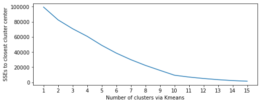

```python
# plot errors by number of clusters
fig,ax = plt.subplots(figsize=(8,3))
plt.plot(range(1,15+1),inertias)
plt.ylabel('SSEs to closest cluster center')
plt.xlabel('Number of clusters via Kmeans')
plt.xticks(range(1,15+1))
plt.show()
```

Looks like 10 would be reasonable based on this method, but it's worth revisiting later.

```python
# Re-fit k-means using 10 clusters
kmeans = KMeans(n_clusters=10, random_state=RANDOM_STATE).fit(df_pcs_10)
```

```python
# Look at the items that are clustered together - do they make sense?
items['cluster'] = kmeans.labels_
item_clusters = items[['item_name','cluster']].groupby('cluster').agg(lambda x: [i for i in x])
for cluster in range(0,10):
    display(item_clusters.loc[cluster,'item_name'])
```

```
['poultry', 'beef', 'pork']
```

```
['sugar', 'pet items']
```

```
['carrots', 'cucumbers', 'broccoli', 'cauliflower']
```

```
['grapefruit', 'cherries', 'apples', 'berries', 'bananas']
```

```
['bagels', 'tortillas', 'dinner rolls', 'sandwich loaves']
```

```
['soda', 'tea', 'juice', 'coffee']
```

```
['butter', 'eggs', 'milk', 'cheeses', 'yogurt']
```

```
['lettuce']
```

```
['baby items',
 'waffles',
 'sandwich bags',
 'cereals',
 'shampoo',
 'aluminum foil',
 'laundry detergent',
 'shaving cream',
 'frozen vegetables',
 'paper towels',
 'dishwashing',
 'hand soap',
 'flour',
 'pasta',
 'toilet paper',
 'soap',
 'ice cream']
```

```
['spaghetti sauce', 'canned vegetables', 'ketchup']
```

These clusters largely seem to make sense (e.g., cllusters seem to group like items together) but also give us some unintuitive combinations that could help with the store layout problem

## Interpreting model results and forming recommendations

```python
# A function we will use a lot...
def get_items_by_clust(clust_num):
    """ returns a list of items given a cluster number (0-9)"""
    display(item_clusters.loc[clust_num,'item_name'])
```

Let's look at clusters which make a lot of sense first:

```python
for c in [0,2,3,4,5,6]:
    get_items_by_clust(c)
```

```
['poultry', 'beef', 'pork']
```

```
['carrots', 'cucumbers', 'broccoli', 'cauliflower']
```

```
['grapefruit', 'cherries', 'apples', 'berries', 'bananas']
```

```
['bagels', 'tortillas', 'dinner rolls', 'sandwich loaves']
```

```
['soda', 'tea', 'juice', 'coffee']
```

```
['butter', 'eggs', 'milk', 'cheeses', 'yogurt']
```

These clusters make a lot of sense but yield no real novel insights - people tend to buy meat together, vegetables together, fruit together, bread together, drinks together, and dairy together.

```python
get_items_by_clust(9)
```

```
['spaghetti sauce', 'canned vegetables', 'ketchup']
```

This cluster is where it starts to get interesting - it seems like it is a proxy for pantry items (i.e., people are remembering to stock up on pantry essentials together). Even though these are all middle-of-store items, this suggests putting them close together in the aisle (or in the same aisles if they aren't already) could be beneficial

```python
get_items_by_clust(1)
```

```
['sugar', 'pet items']
```

Similar idea here. Putting sugar nearby the pet items (either in the same aisle or in adjacent aisle) would be good.

```python
get_items_by_clust(8)
```

```
['baby items',
 'waffles',
 'sandwich bags',
 'cereals',
 'shampoo',
 'aluminum foil',
 'laundry detergent',
 'shaving cream',
 'frozen vegetables',
 'paper towels',
 'dishwashing',
 'hand soap',
 'flour',
 'pasta',
 'toilet paper',
 'soap',
 'ice cream']
```

This is a big cluster, and might represent remaining items which do not fit cleanly into others. Still, there are some commonalities, e.g., household essentials (sandwich bags, aluminum foil), cleaning supplies (laundry detergent, soap, dishwashing, paper towels, toilet paper), dry goods (flour, pasta, waffles), and frozen goods (ice cream, frozen vegetables).

This cluster could be interpreted perhaps as "items for families", but this hypothesis would need to be evaluated further. In any case, grouping the household essentials, cleaning supplies, and dry goods nearby the frozen goods section (e.g., with endcaps, or in close-by aisles) comes from this.

```python
get_items_by_clust(7)
```

```
['lettuce']
```

## Validation

```python
# Compare item frequency by carts
def pct_carts_in(item_id1,item_id2):
    """For any two items, return percentage of total carts they were in """
    are_items_together = users.loc[:,'id']\
        .map(lambda x: True if (item_id1 in x.split(',') and item_id2 in x.split(','))
                       else False)
    return are_items_together.mean()
```

```python
# get item ids for item names
display(items.loc[items['item_name'].map(lambda x: x in ['spaghetti sauce', 'canned vegetables', 'ketchup','pasta'])])

#Frequency of appearing together for spaghetti sauce, canned vegetables, and ketchup
print(pct_carts_in('26','28'))
print(pct_carts_in('26','41'))
print(pct_carts_in('28','41'))

#Frequency of appearing together for spaghetti sauce and pasta
print(pct_carts_in('26','31'))
```

|  | item_name | Item_id | price | cluster |
| --- | --- | --- | --- | --- |
| 25 | spaghetti sauce | 26 | 2 | 9 |
| 27 | canned vegetables | 28 | 1 | 9 |
| 30 | pasta | 31 | 1 | 8 |
| 40 | ketchup | 41 | 1 | 9 |

```
0.05086892638192228
0.050286264376551655
0.04980493489385418
0.012818564118153722
```

Spaghetti sauce, canned vegetables, and ketchup appeared in 5% of carts.

Spaghetti sauce and pasta only appeared in 1% of carts!

==> Clustering identified groupings based on purchase history counter to what we might expect!

## What about the prices of the items in this cluster?

```python
# Modify the above function to return the prices of the items by the cluster
item_price_clusters = items[['cluster','price']].groupby('cluster').agg(lambda x: [i for i in x])

def get_prices_by_clust(clust_num):
    """ returns a list of prices given a cluster number (0-9)"""
    display(item_price_clusters.loc[clust_num,'price'])
```

```python
for i in range(10):
    get_items_by_clust(i)
    get_prices_by_clust(i)
```

```
['poultry', 'beef', 'pork']
```

```
[4, 4, 4]
```

```
['sugar', 'pet items']
```

```
[2, 2]
```

```
['carrots', 'cucumbers', 'broccoli', 'cauliflower']
```

```
[1, 1, 1, 1]
```

```
['grapefruit', 'cherries', 'apples', 'berries', 'bananas']
```

```
[2, 3, 2, 3, 1]
```

```
['bagels', 'tortillas', 'dinner rolls', 'sandwich loaves']
```

```
[2, 2, 2, 2]
```

```
['soda', 'tea', 'juice', 'coffee']
```

```
[1, 3, 3, 5]
```

```
['butter', 'eggs', 'milk', 'cheeses', 'yogurt']
```

```
[3, 2, 3, 2, 1]
```

```
['lettuce']
```

```
[1]
```

```
['baby items',
 'waffles',
 'sandwich bags',
 'cereals',
 'shampoo',
 'aluminum foil',
 'laundry detergent',
 'shaving cream',
 'frozen vegetables',
 'paper towels',
 'dishwashing',
 'hand soap',
 'flour',
 'pasta',
 'toilet paper',
 'soap',
 'ice cream']
```

```
[4, 2, 3, 3, 3, 4, 7, 2, 1, 2, 6, 3, 2, 1, 2, 3, 3]
```

```
['spaghetti sauce', 'canned vegetables', 'ketchup']
```

```
[2, 1, 1]
```

Pricing information could identify how to bundle items together (e.g., a lower-priced "add-on" item to a more expensive purchase). *Examples:* soda (1) with coffee (5); bananas (1) with cherries (3).

Or groups of items (e.g., buy 3 get 1 free). *Examples:* ['carrots', 'cucumbers', 'broccoli', 'cauliflower'] (all 1)

# Final Recommendations:

1. Spaghetti sauce, canned vegetables, and ketchup are being purchased together - put them together.
2. Put sugar in the pet food aisle.
3. Put items for families (e.g., household essentials, cleaning supplies, dry goods) together near the frozen food aisle.
4. Meat, vegetables, fruit, bread, drinks, and dairy are being purchased together. Keep those areas of the store the same.